# **Problem Statement**

## Business Context

A sales forecast is a prediction of future sales revenue based on historical data, industry trends, and the status of the current sales pipeline. Businesses use the sales forecast to estimate weekly, monthly, quarterly, and annual sales totals. A company needs to make an accurate sales forecast as it adds value across an organization and helps the different verticals to chalk out their future course of action.

Forecasting helps an organization plan its sales operations by region and provides valuable insights to the supply chain team regarding the procurement of goods and materials. An accurate sales forecast process has many benefits which include improved decision-making about the future and reduction of sales pipeline and forecast risks. Moreover, it helps to reduce the time spent in planning territory coverage and establish benchmarks that can be used to assess trends in the future.

## Objective

SuperKart is a retail chain operating supermarkets and food marts across various tier cities, offering a wide range of products. To optimize its inventory management and make informed decisions around regional sales strategies, SuperKart wants to accurately forecast the sales revenue of its outlets for the upcoming quarter.

To operationalize these insights at scale, the company has partnered with a data science firm—not just to build a predictive model based on historical sales data, but to develop and deploy a robust forecasting solution that can be integrated into SuperKart’s decision-making systems and used across its network of stores.

## Data Description

The data contains the different attributes of the various products and stores.The detailed data dictionary is given below.

- **Product_Id** - unique identifier of each product, each identifier having two letters at the beginning followed by a number.
- **Product_Weight** - weight of each product
- **Product_Sugar_Content** - sugar content of each product like low sugar, regular and no sugar
- **Product_Allocated_Area** - ratio of the allocated display area of each product to the total display area of all the products in a store
- **Product_Type** - broad category for each product like meat, snack foods, hard drinks, dairy, canned, soft drinks, health and hygiene, baking goods, bread, breakfast, frozen foods, fruits and vegetables, household, seafood, starchy foods, others
- **Product_MRP** - maximum retail price of each product
- **Store_Id** - unique identifier of each store
- **Store_Establishment_Year** - year in which the store was established
- **Store_Size** - size of the store depending on sq. feet like high, medium and low
- **Store_Location_City_Type** - type of city in which the store is located like Tier 1, Tier 2 and Tier 3. Tier 1 consists of cities where the standard of living is comparatively higher than its Tier 2 and Tier 3 counterparts.
- **Store_Type** - type of store depending on the products that are being sold there like Departmental Store, Supermarket Type 1, Supermarket Type 2 and Food Mart
- **Product_Store_Sales_Total** - total revenue generated by the sale of that particular product in that particular store

# **Installing and Importing the necessary libraries**

```python
# Required package versions are listed here for Colab. Uncomment if installation is needed.
# !pip install numpy==2.0.2 pandas==2.2.2 scikit-learn==1.6.1 matplotlib==3.10.0 seaborn==0.13.2 joblib==1.4.2 xgboost==2.1.4 requests==2.32.4 huggingface_hub==0.34.0 -q
```

**Note:**

- After running the above cell, kindly restart the notebook kernel (for Jupyter Notebook) or runtime (for Google Colab) and run all cells sequentially from the next cell.
- On executing the above line of code, you might see a warning regarding package dependencies. This error message can be ignored as the above code ensures that all necessary libraries and their dependencies are maintained to successfully execute the code in this notebook.

```python
import warnings
warnings.filterwarnings("ignore")

# Libraries to help with reading and manipulating data
import numpy as np
import pandas as pd

# For splitting the dataset
from sklearn.model_selection import train_test_split

# Libaries to help with data visualization
import matplotlib.pyplot as plt
import seaborn as sns

# Removes the limit for the number of displayed columns
pd.set_option("display.max_columns", None)
# Sets the limit for the number of displayed rows
pd.set_option("display.max_rows", 100)


# Libraries different ensemble classifiers
from sklearn.ensemble import (
    BaggingRegressor,
    RandomForestRegressor,
    AdaBoostRegressor,
    GradientBoostingRegressor,
)
from xgboost import XGBRegressor
from sklearn.tree import DecisionTreeRegressor

# Libraries to get different metric scores
from sklearn.metrics import (
    confusion_matrix,
    accuracy_score,
    precision_score,
    recall_score,
    f1_score,
    mean_squared_error,
    mean_absolute_error,
    r2_score,
    mean_absolute_percentage_error
)

# To create the pipeline
from sklearn.compose import make_column_transformer
from sklearn.pipeline import make_pipeline,Pipeline

# To tune different models and standardize
from sklearn.model_selection import GridSearchCV
from sklearn.preprocessing import StandardScaler,OneHotEncoder

# To serialize the model
import joblib

# os related functionalities
import os

# API request
import requests

# for hugging face space authentication to upload files
from huggingface_hub import login, HfApi
```

# **Loading the dataset**

```python
data = pd.read_csv('/content/sample_data/SuperKart.csv')
data.head()
```

|  | Product_Id | Product_Weight | Product_Sugar_Content | Product_Allocated_Area | Product_Type | Product_MRP | Store_Id | Store_Establishment_Year | Store_Size | Store_Location_City_Type | Store_Type | Product_Store_Sales_Total |
| --- | --- | --- | --- | --- | --- | --- | --- | --- | --- | --- | --- | --- |
| 0 | FD6114 | 12.66 | Low Sugar | 0.027 | Frozen Foods | 117.08 | OUT004 | 2009 | Medium | Tier 2 | Supermarket Type2 | 2842.40 |
| 1 | FD7839 | 16.54 | Low Sugar | 0.144 | Dairy | 171.43 | OUT003 | 1999 | Medium | Tier 1 | Departmental Store | 4830.02 |
| 2 | FD5075 | 14.28 | Regular | 0.031 | Canned | 162.08 | OUT001 | 1987 | High | Tier 2 | Supermarket Type1 | 4130.16 |
| 3 | FD8233 | 12.10 | Low Sugar | 0.112 | Baking Goods | 186.31 | OUT001 | 1987 | High | Tier 2 | Supermarket Type1 | 4132.18 |
| 4 | NC1180 | 9.57 | No Sugar | 0.010 | Health and Hygiene | 123.67 | OUT002 | 1998 | Small | Tier 3 | Food Mart | 2279.36 |

# **Data Overview**

```python
print(f'Dataset shape: {data.shape}')
display(data.info())
display(data.describe(include='all').T)
print('Missing values:')
display(data.isnull().sum())
print('Duplicate rows:', data.duplicated().sum())
```

```
Dataset shape: (8763, 12)
<class 'pandas.core.frame.DataFrame'>
RangeIndex: 8763 entries, 0 to 8762
Data columns (total 12 columns):
 #   Column                     Non-Null Count  Dtype
---  ------                     --------------  -----
 0   Product_Id                 8763 non-null   object
 1   Product_Weight             8763 non-null   float64
 2   Product_Sugar_Content      8763 non-null   object
 3   Product_Allocated_Area     8763 non-null   float64
 4   Product_Type               8763 non-null   object
 5   Product_MRP                8763 non-null   float64
 6   Store_Id                   8763 non-null   object
 7   Store_Establishment_Year   8763 non-null   int64
 8   Store_Size                 8763 non-null   object
 9   Store_Location_City_Type   8763 non-null   object
 10  Store_Type                 8763 non-null   object
 11  Product_Store_Sales_Total  8763 non-null   float64
dtypes: float64(4), int64(1), object(7)
memory usage: 821.7+ KB
```

```
None
```

|  | count | unique | top | freq | mean | std | min | 25% | 50% | 75% | max |
| --- | --- | --- | --- | --- | --- | --- | --- | --- | --- | --- | --- |
| Product_Id | 8763 | 8763 | FD306 | 1 | NaN | NaN | NaN | NaN | NaN | NaN | NaN |
| Product_Weight | 8763.0 | NaN | NaN | NaN | 12.653792 | 2.21732 | 4.0 | 11.15 | 12.66 | 14.18 | 22.0 |
| Product_Sugar_Content | 8763 | 4 | Low Sugar | 4885 | NaN | NaN | NaN | NaN | NaN | NaN | NaN |
| Product_Allocated_Area | 8763.0 | NaN | NaN | NaN | 0.068786 | 0.048204 | 0.004 | 0.031 | 0.056 | 0.096 | 0.298 |
| Product_Type | 8763 | 16 | Fruits and Vegetables | 1249 | NaN | NaN | NaN | NaN | NaN | NaN | NaN |
| Product_MRP | 8763.0 | NaN | NaN | NaN | 147.032539 | 30.69411 | 31.0 | 126.16 | 146.74 | 167.585 | 266.0 |
| Store_Id | 8763 | 4 | OUT004 | 4676 | NaN | NaN | NaN | NaN | NaN | NaN | NaN |
| Store_Establishment_Year | 8763.0 | NaN | NaN | NaN | 2002.032751 | 8.388381 | 1987.0 | 1998.0 | 2009.0 | 2009.0 | 2009.0 |
| Store_Size | 8763 | 3 | Medium | 6025 | NaN | NaN | NaN | NaN | NaN | NaN | NaN |
| Store_Location_City_Type | 8763 | 3 | Tier 2 | 6262 | NaN | NaN | NaN | NaN | NaN | NaN | NaN |
| Store_Type | 8763 | 4 | Supermarket Type2 | 4676 | NaN | NaN | NaN | NaN | NaN | NaN | NaN |
| Product_Store_Sales_Total | 8763.0 | NaN | NaN | NaN | 3464.00364 | 1065.630494 | 33.0 | 2761.715 | 3452.34 | 4145.165 | 8000.0 |

```
Missing values:
```

|  | 0 |
| --- | --- |
| Product_Id | 0 |
| Product_Weight | 0 |
| Product_Sugar_Content | 0 |
| Product_Allocated_Area | 0 |
| Product_Type | 0 |
| Product_MRP | 0 |
| Store_Id | 0 |
| Store_Establishment_Year | 0 |
| Store_Size | 0 |
| Store_Location_City_Type | 0 |
| Store_Type | 0 |
| Product_Store_Sales_Total | 0 |

**dtype:** int64

```
Duplicate rows: 0
```

# **Exploratory Data Analysis (EDA)**

## Univariate Analysis

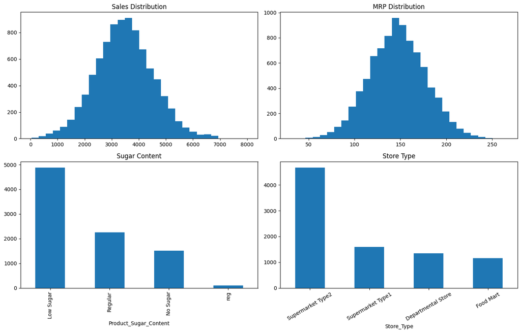

```
Product_Sugar_Content
Low Sugar    4885
Regular      2251
No Sugar     1519
reg           108
Name: count, dtype: int64
Product_Type
Fruits and Vegetables    1249
Snack Foods              1149
Frozen Foods              811
Dairy                     796
Household                 740
Baking Goods              716
Canned                    677
Health and Hygiene        628
Meat                      618
Soft Drinks               519
Breads                    200
Hard Drinks               186
Others                    151
Starchy Foods             141
Breakfast                 106
Seafood                    76
Name: count, dtype: int64
```

```python
fig, axes = plt.subplots(2, 2, figsize=(14, 9))
axes[0,0].hist(data['Product_Store_Sales_Total'], bins=30); axes[0,0].set_title('Sales Distribution')
axes[0,1].hist(data['Product_MRP'], bins=30); axes[0,1].set_title('MRP Distribution')
data['Product_Sugar_Content'].value_counts().plot(kind='bar', ax=axes[1,0], title='Sugar Content')
data['Store_Type'].value_counts().plot(kind='bar', ax=axes[1,1], title='Store Type')
axes[1,1].tick_params(axis='x', rotation=30)
plt.tight_layout(); plt.show()
print(data['Product_Sugar_Content'].value_counts())
print(data['Product_Type'].value_counts())
```

## Bivariate Analysis

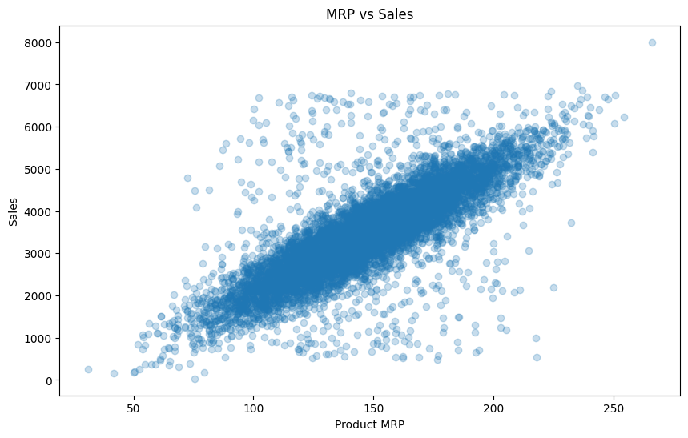

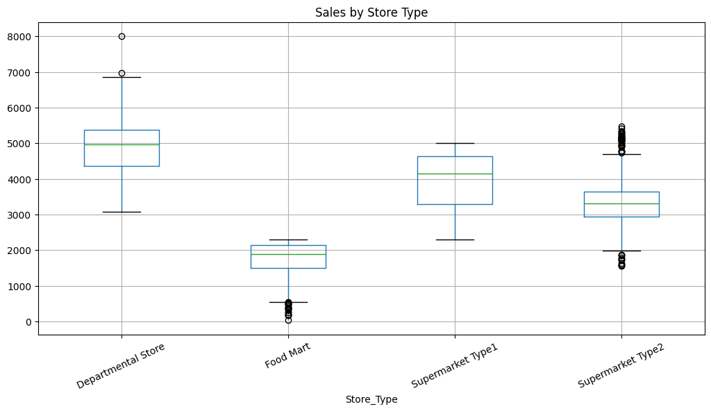

```
Store_Type
Departmental Store    4946.966323
Supermarket Type1     3923.778802
Supermarket Type2     3299.312111
Food Mart             1762.942465
Name: Product_Store_Sales_Total, dtype: float64
Product_Store_Sales_Total    1.000000
Product_MRP                  0.787989
Product_Weight               0.737955
Product_Allocated_Area      -0.000933
Store_Establishment_Year    -0.185027
Name: Product_Store_Sales_Total, dtype: float64
```

```python
plt.figure(figsize=(10,6))
plt.scatter(data['Product_MRP'], data['Product_Store_Sales_Total'], alpha=.25)
plt.xlabel('Product MRP'); plt.ylabel('Sales'); plt.title('MRP vs Sales'); plt.show()
data.boxplot(column='Product_Store_Sales_Total', by='Store_Type', figsize=(12,6), rot=25)
plt.suptitle(''); plt.title('Sales by Store Type'); plt.show()
print(data.groupby('Store_Type')['Product_Store_Sales_Total'].mean().sort_values(ascending=False))
print(data.select_dtypes(include=np.number).corr()['Product_Store_Sales_Total'].sort_values(ascending=False))
```

# **Data Preprocessing**

```python
df = data.copy()
# Normalize inconsistent sugar-content labels
df['Product_Sugar_Content'] = df['Product_Sugar_Content'].replace({'reg':'Regular'})
# Engineer deployment-friendly features
df['Product_Id_char'] = df['Product_Id'].str[:2]
df['Store_Age_Years'] = 2025 - df['Store_Establishment_Year']
perishable = ['Dairy','Meat','Fruits and Vegetables','Breakfast','Breads','Seafood']
df['Product_Type_Category'] = np.where(df['Product_Type'].isin(perishable), 'Perishables', 'Non Perishables')
# Remove identifiers / columns replaced by engineered features
df.drop(columns=['Product_Id','Store_Id','Store_Establishment_Year','Product_Type'], inplace=True)
X = df.drop(columns='Product_Store_Sales_Total')
y = df['Product_Store_Sales_Total']
X_train, X_test, y_train, y_test = train_test_split(X, y, test_size=0.20, random_state=42)
cat_cols = X.select_dtypes(include='object').columns.tolist()
num_cols = X.select_dtypes(exclude='object').columns.tolist()
preprocessor = make_column_transformer((OneHotEncoder(handle_unknown='ignore'), cat_cols),(StandardScaler(), num_cols), remainder='drop')
print('Features:', X.columns.tolist())
print('Train/Test:', X_train.shape, X_test.shape)
```

```
Features: ['Product_Weight', 'Product_Sugar_Content', 'Product_Allocated_Area', 'Product_MRP', 'Store_Size', 'Store_Location_City_Type', 'Store_Type', 'Product_Id_char', 'Store_Age_Years', 'Product_Type_Category']
Train/Test: (7010, 10) (1753, 10)
```

# **Model Building**

## Define functions for Model Evaluation

```python
# function to compute adjusted R-squared
def adj_r2_score(predictors, targets, predictions):
    r2 = r2_score(targets, predictions)
    n = predictors.shape[0]
    k = predictors.shape[1]
    return 1 - ((1 - r2) * (n - 1) / (n - k - 1))


# function to compute different metrics to check performance of a regression model
def model_performance_regression(model, predictors, target):
    """
    Function to compute different metrics to check regression model performance

    model: regressor
    predictors: independent variables
    target: dependent variable
    """

    # predicting using the independent variables
    pred = model.predict(predictors)

    r2 = r2_score(target, pred)  # to compute R-squared
    adjr2 = adj_r2_score(predictors, target, pred)  # to compute adjusted R-squared
    rmse = np.sqrt(mean_squared_error(target, pred))  # to compute RMSE
    mae = mean_absolute_error(target, pred)  # to compute MAE
    mape = mean_absolute_percentage_error(target, pred)  # to compute MAPE

    # creating a dataframe of metrics
    df_perf = pd.DataFrame(
        {
            "RMSE": rmse,
            "MAE": mae,
            "R-squared": r2,
            "Adj. R-squared": adjr2,
            "MAPE": mape,
        },
        index=[0],
    )

    return df_perf
```

The ML models to be built can be any two out of the following:

1. Decision Tree
2. Bagging
3. Random Forest
4. AdaBoost
5. Gradient Boosting
6. XGBoost

```python
models = {
    'Random Forest': RandomForestRegressor(n_estimators=100, random_state=42, n_jobs=-1),
    'Gradient Boosting': GradientBoostingRegressor(random_state=42)
}
model_results = {}
fitted_models = {}
for name, reg in models.items():
    pipe = make_pipeline(preprocessor, reg)
    pipe.fit(X_train, y_train)
    fitted_models[name] = pipe
    perf = model_performance_regression(pipe, X_test, y_test)
    model_results[name] = perf.iloc[0]
results_df = pd.DataFrame(model_results).T.sort_values('RMSE')
results_df
```

|  | RMSE | MAE | R-squared | Adj. R-squared | MAPE |
| --- | --- | --- | --- | --- | --- |
| Random Forest | 286.233369 | 110.251019 | 0.928196 | 0.927784 | 0.039533 |
| Gradient Boosting | 308.731831 | 144.089466 | 0.916465 | 0.915985 | 0.050587 |

# **Model Performance Improvement - Hyperparameter Tuning**

```python
# Tune Gradient Boosting with a compact cross-validated grid
gb_pipe = Pipeline([('preprocessor', preprocessor), ('model', GradientBoostingRegressor(random_state=42))])
param_grid = {'model__n_estimators':[100,150], 'model__learning_rate':[0.05,0.1], 'model__max_depth':[2,3]}
grid = GridSearchCV(gb_pipe, param_grid, cv=3, scoring='neg_root_mean_squared_error', n_jobs=1)
grid.fit(X_train, y_train)
best_model = grid.best_estimator_
print('Best parameters:', grid.best_params_)
tuned_performance = model_performance_regression(best_model, X_test, y_test)
tuned_performance
```

```
Best parameters: {'model__learning_rate': 0.1, 'model__max_depth': 3, 'model__n_estimators': 150}
```

|  | RMSE | MAE | R-squared | Adj. R-squared | MAPE |
| --- | --- | --- | --- | --- | --- |
| 0 | 308.238349 | 139.357937 | 0.916732 | 0.916254 | 0.048759 |

# **Model Performance Comparison, Final Model Selection, and Serialization**

```python
comparison = results_df.copy()
comparison.loc['Tuned Gradient Boosting'] = tuned_performance.iloc[0]
display(comparison.sort_values('RMSE'))
# Select the model with the lowest test RMSE
final_model_name = comparison['RMSE'].idxmin()
final_model = best_model if final_model_name == 'Tuned Gradient Boosting' else fitted_models[final_model_name]
joblib.dump(final_model, 'superkart_model.joblib')
print(f'Final model: {final_model_name}')
print('Final model saved as superkart_model.joblib')
```

|  | RMSE | MAE | R-squared | Adj. R-squared | MAPE |
| --- | --- | --- | --- | --- | --- |
| Random Forest | 286.233369 | 110.251019 | 0.928196 | 0.927784 | 0.039533 |
| Tuned Gradient Boosting | 308.238349 | 139.357937 | 0.916732 | 0.916254 | 0.048759 |
| Gradient Boosting | 308.731831 | 144.089466 | 0.916465 | 0.915985 | 0.050587 |

```
Final model: Random Forest
Final model saved as superkart_model.joblib
```

# **Deployment - Backend**

## Points to note before executing the below cells

- Create a GitHub account if you don't already have one at github.com
- Generate a **Personal Access Token**
  - Make sure the token has **repo** scope (full control of private repositories)
- The serialized ML model file (`superkart_model.joblib`) should already be present in the `backend_files` folder before pushing to GitHub
- We will deploy **both the Flask backend and the Streamlit frontend as separate Docker containers** inside a GitHub Codespace, and connect them using a **Docker network**

## Flask Web Framework

Flask is a lightweight, flexible Python web framework used to build web applications and APIs quickly and easily.

Flask allows you to:

- Create web routes (URLs that users can access)
- Handle HTTP requests and responses
- Build REST APIs to expose machine learning models or other services

```python
backend_app = r'''from flask import Flask, request, jsonify
import pandas as pd
import joblib

superkart_api = Flask(__name__)
model = joblib.load('superkart_model.joblib')
FEATURES = ['Product_Weight','Product_Sugar_Content','Product_Allocated_Area','Product_MRP','Store_Size','Store_Location_City_Type','Store_Type','Product_Id_char','Store_Age_Years','Product_Type_Category']

@superkart_api.get('/health')
def health():
    return jsonify({'status':'ok'})

@superkart_api.post('/v1/predict')
def predict():
    payload = request.get_json(force=True)
    frame = pd.DataFrame([payload])[FEATURES]
    pred = float(model.predict(frame)[0])
    return jsonify({'predicted_sales': pred})

@superkart_api.post('/v1/predictbatch')
def predict_batch():
    frame = pd.read_csv(request.files['file'])[FEATURES]
    preds = model.predict(frame)
    return jsonify({str(i): float(v) for i, v in enumerate(preds)})

if __name__ == '__main__':
    superkart_api.run(host='0.0.0.0', port=7860)
'''
os.makedirs('backend_files', exist_ok=True)
open('backend_files/app.py','w').write(backend_app)
joblib.dump(final_model, 'backend_files/superkart_model.joblib')
print(backend_app)
```

```
from flask import Flask, request, jsonify
import pandas as pd
import joblib

superkart_api = Flask(__name__)
model = joblib.load('superkart_model.joblib')
FEATURES = ['Product_Weight','Product_Sugar_Content','Product_Allocated_Area','Product_MRP','Store_Size','Store_Location_City_Type','Store_Type','Product_Id_char','Store_Age_Years','Product_Type_Category']

@superkart_api.get('/health')
def health():
    return jsonify({'status':'ok'})

@superkart_api.post('/v1/predict')
def predict():
    payload = request.get_json(force=True)
    frame = pd.DataFrame([payload])[FEATURES]
    pred = float(model.predict(frame)[0])
    return jsonify({'predicted_sales': pred})

@superkart_api.post('/v1/predictbatch')
def predict_batch():
    frame = pd.read_csv(request.files['file'])[FEATURES]
    preds = model.predict(frame)
    return jsonify({str(i): float(v) for i, v in enumerate(preds)})

if __name__ == '__main__':
    superkart_api.run(host='0.0.0.0', port=7860)
```

## Dependencies File

```python
backend_requirements = '''flask==3.1.0
pandas==2.2.2
scikit-learn==1.6.1
joblib==1.4.2
gunicorn==23.0.0
'''
open('backend_files/requirements.txt','w').write(backend_requirements)
print(backend_requirements)
```

```
flask==3.1.0
pandas==2.2.2
scikit-learn==1.6.1
joblib==1.4.2
gunicorn==23.0.0
```

## Dockerfile

```python
backend_dockerfile = '''FROM python:3.11-slim
WORKDIR /app
COPY requirements.txt .
RUN pip install --no-cache-dir -r requirements.txt
COPY . .
EXPOSE 7860
CMD ["gunicorn", "--bind", "0.0.0.0:7860", "app:superkart_api"]
'''
open('backend_files/Dockerfile','w').write(backend_dockerfile)
print(backend_dockerfile)
```

```
FROM python:3.11-slim
WORKDIR /app
COPY requirements.txt .
RUN pip install --no-cache-dir -r requirements.txt
COPY . .
EXPOSE 7860
CMD ["gunicorn", "--bind", "0.0.0.0:7860", "app:superkart_api"]
```

# **Deployment - Frontend**

## Streamlit for Interactive UI

```python
frontend_app = r'''import streamlit as st
import requests

st.title('SuperKart Sales Forecast')
api_url = st.text_input('Backend URL', 'http://backend:7860')
with st.form('prediction_form'):
    weight = st.number_input('Product Weight', min_value=0.0, value=12.66)
    sugar = st.selectbox('Sugar Content', ['Low Sugar','Regular','No Sugar'])
    area = st.number_input('Allocated Area', min_value=0.0, value=0.027, format='%.3f')
    mrp = st.number_input('Product MRP', min_value=0.0, value=117.08)
    size = st.selectbox('Store Size', ['Small','Medium','High'])
    city = st.selectbox('City Type', ['Tier 1','Tier 2','Tier 3'])
    store = st.selectbox('Store Type', ['Supermarket Type1','Supermarket Type2','Departmental Store','Food Mart'])
    pid = st.selectbox('Product ID Prefix', ['FD','DR','NC'])
    age = st.number_input('Store Age (Years)', min_value=0, value=16)
    category = st.selectbox('Product Type Category', ['Perishables','Non Perishables'])
    submitted = st.form_submit_button('Predict Sales')
if submitted:
    payload = {'Product_Weight':weight,'Product_Sugar_Content':sugar,'Product_Allocated_Area':area,'Product_MRP':mrp,'Store_Size':size,'Store_Location_City_Type':city,'Store_Type':store,'Product_Id_char':pid,'Store_Age_Years':age,'Product_Type_Category':category}
    r = requests.post(api_url.rstrip('/') + '/v1/predict', json=payload, timeout=30)
    r.raise_for_status()
    st.success(f"Predicted sales: {r.json()['predicted_sales']:,.2f}")
'''
os.makedirs('frontend_files', exist_ok=True)
open('frontend_files/app.py','w').write(frontend_app)
print(frontend_app)
```

```
import streamlit as st
import requests

st.title('SuperKart Sales Forecast')
api_url = st.text_input('Backend URL', 'http://backend:7860')
with st.form('prediction_form'):
    weight = st.number_input('Product Weight', min_value=0.0, value=12.66)
    sugar = st.selectbox('Sugar Content', ['Low Sugar','Regular','No Sugar'])
    area = st.number_input('Allocated Area', min_value=0.0, value=0.027, format='%.3f')
    mrp = st.number_input('Product MRP', min_value=0.0, value=117.08)
    size = st.selectbox('Store Size', ['Small','Medium','High'])
    city = st.selectbox('City Type', ['Tier 1','Tier 2','Tier 3'])
    store = st.selectbox('Store Type', ['Supermarket Type1','Supermarket Type2','Departmental Store','Food Mart'])
    pid = st.selectbox('Product ID Prefix', ['FD','DR','NC'])
    age = st.number_input('Store Age (Years)', min_value=0, value=16)
    category = st.selectbox('Product Type Category', ['Perishables','Non Perishables'])
    submitted = st.form_submit_button('Predict Sales')
if submitted:
    payload = {'Product_Weight':weight,'Product_Sugar_Content':sugar,'Product_Allocated_Area':area,'Product_MRP':mrp,'Store_Size':size,'Store_Location_City_Type':city,'Store_Type':store,'Product_Id_char':pid,'Store_Age_Years':age,'Product_Type_Category':category}
    r = requests.post(api_url.rstrip('/') + '/v1/predict', json=payload, timeout=30)
    r.raise_for_status()
    st.success(f"Predicted sales: {r.json()['predicted_sales']:,.2f}")
```

## Dependencies File

```python
frontend_requirements = '''streamlit==1.44.0
requests==2.32.4
'''
open('frontend_files/requirements.txt','w').write(frontend_requirements)
print(frontend_requirements)
```

```
streamlit==1.44.0
requests==2.32.4
```

## Dockerfile

```python
frontend_dockerfile = '''FROM python:3.11-slim
WORKDIR /app
COPY requirements.txt .
RUN pip install --no-cache-dir -r requirements.txt
COPY . .
EXPOSE 8501
CMD ["streamlit", "run", "app.py", "--server.address=0.0.0.0"]
'''
open('frontend_files/Dockerfile','w').write(frontend_dockerfile)
print(frontend_dockerfile)
```

```
FROM python:3.11-slim
WORKDIR /app
COPY requirements.txt .
RUN pip install --no-cache-dir -r requirements.txt
COPY . .
EXPOSE 8501
CMD ["streamlit", "run", "app.py", "--server.address=0.0.0.0"]
```

# **Pushing Deployment Files to GitHub**

```python
# Run these commands after replacing placeholders with your GitHub details.
# Never paste a Personal Access Token into a notebook you will submit.
print('''GitHub/Codespaces steps:
1. Create a repository and upload backend_files/ and frontend_files/.
2. Open the repository in a Codespace.
3. Build both Docker images and create a shared Docker network.
4. Run backend on port 7860 and frontend on port 8501.
5. Make forwarded ports public if required by the assignment.
''')
```

```
GitHub/Codespaces steps:
1. Create a repository and upload backend_files/ and frontend_files/.
2. Open the repository in a Codespace.
3. Build both Docker images and create a shared Docker network.
4. Run backend on port 7860 and frontend on port 8501.
5. Make forwarded ports public if required by the assignment.
```

# **Inferencing using Flask API**

As the **frontend and backend are decoupled**, we can **access the backend directly for predictions**.

- The decoupling ensures seamless interaction with the deployed model while leveraging the API for scalable inference.

Let's see how to interact with the deployed Flask API running inside a GitHub Codespace to perform **online** and **batch inference** from this Colab notebook.

We will:

1. Send API requests for both online and batch inference.
2. Process and check the model predictions.

**Before running the cells below**, make sure:

- Your Codespace is running with both containers up
- Port 7860 has been set to **Public** in the Codespace Ports tab
- You have copied the forwarded URL for port 7860
- You have also referred the document titled **`Guided Hands-on - Containerized Model Deployment using GitHub Codespaces`** provided

```python
import json  # To handle JSON formatting for API requests and responses
import requests  # To send HTTP requests to the deployed Flask API

import pandas as pd  # For data manipulation and analysis
import numpy as np  # For numerical computations
```

```python
model_root_url = 'https://sturdy-goldfish-q945795w6553xwpx-7860.app.github.dev'  # e.g. https://<codespace-name>-7860.app.github.dev
```

Replace the URL above with the actual forwarded URL from your Codespace's Ports tab. It will look something like `https://organic-space-abcd1234-7860.app.github.dev`. Make sure there is no trailing slash at the end.

This URL is a tunnel that Codespaces creates to route external HTTP requests into your Codespace and to the Flask container running on port 7860.

```python
model_url = model_root_url + "/v1/predict"  # Endpoint for online (single) inference
```

Since our model predictions are provided by the following endpoint we created using Flask, we need to invoke the same to make prediction.

> `@superkart_api.post('/v1/predict')`

```python
model_batch_url = model_root_url + "/v1/predictbatch"  # Endpoint for batch inference
```

> `@superkart_api.post('/v1/predictbatch')`

## Online

**Online Inference:** Sending a single request to the API and receiving an immediate response. This is useful for real-time applications like recommendation systems and fraud detection.

- This data is sent as a JSON payload in a POST request to the model endpoint.
- The model processes the input features and returns a prediction.

```python
payload = {
  "Product_Weight": 12.66,
  "Product_Sugar_Content": "Low Sugar",
  "Product_Allocated_Area": 0.027,
  "Product_MRP": 117.08,
  "Store_Size": "Medium",
  "Store_Location_City_Type": "Tier 2",
  "Store_Type": "Supermarket Type2",
  "Product_Id_char": "FD",
  "Store_Age_Years": 16,
  "Product_Type_Category": "Non Perishables"
}
```

```python
if model_root_url.startswith('YOUR_'):
    print('Add your Codespace port 7860 URL in cell 53, then rerun this cell.')
    response = None
else:
    response = requests.post(model_url, json=payload, timeout=30)
```

```python
response if response is not None else 'API call skipped until Codespace URL is supplied.'
```

```
<Response [200]>
```

`<Response [200]>` indicates that the HTTP request was successful.

- `Response` is the object returned by `requests.post()`.
- `[200]` is the HTTP status code, meaning **OK** (the request was processed successfully).

```python
print(response.json()) if response is not None else print('API call skipped until Codespace URL is supplied.')
```

```
{'predicted_sales': 2950.9262000000003}
```

`response.json()` is used to parse the response body as JSON.

- If the API returns data in JSON format, `.json()` converts it into a Python dictionary.
- This allows easy access to specific values using keys.